# Bayesian modelling of ejectives and uvulars (presence / absence) depending on altitude

Matthias Urban  
21 September, 2020

# Overview

This document describes the Bayesian modelling of ejectives and uvulars (presence / absence) depending on altitude and ancillary analyses

# Required packages

```r
library(tidyverse)
library(brms)
library(boot)
library(jaccard)
```

```r
library(ggplot2)
```

# Data preparation

Read in data

```r
elevdata <- read.csv('../Data/uvulars_ejectives_pruned2.csv', header =T)
```

Change separator from comma to dot for coordinates and treat as numeric

```r
elevdata$latitude<-as.numeric(gsub(',','.',elevdata$latitude))
elevdata$longitude<-as.numeric(gsub(',','.',elevdata$longitude))
```

Treat macroareas as factors

```r
elevdata$macroarea2<-as.factor(elevdata$macroarea2)
```

Reduce the data to a binary distinction between presence vs. absence of ejectives/uvulars

```r
elevdata<-mutate(elevdata, NonMarginal01 = as.logical(Nonmarginal_Uvular), NonMarginal01 = as.numeric(NonMarginal01))
elevdata<-mutate(elevdata, NonMarginal02 = as.logical(Nonmarginal_Ejective), NonMarginal02 = as.numeric(NonMarginal02))
```

# Modeling

## Bayesian logistic mixed effects regressions

Tranform elevation to its log10 for modelling

```r
elevdata <- mutate(elevdata, elevationlog10 = log10(elevation))
```

Set prior

```r
priors <-set_prior("normal(0, 2)", class="b", coef="elevationlog10")
```

### Model for uvulars

```r
elevmodeluvulars<-brm(NonMarginal01 ~ elevationlog10 + (1+ elevationlog10| macroarea2) +(1|family_id), family= 'bernoulli', data=elevdata, warmup=6000, iter=8000, chains=4, prior=priors, control = list(adapt_delta = 0.99))
```

[output not shown]

[output cut: 51 more lines]

[output not shown]

Model assessment and checks

check Rhat and ESS values

```r
summary(elevmodeluvulars)
```

```
##  Family: bernoulli
##   Links: mu = logit
## Formula: NonMarginal01 ~ elevationlog10 + (1 + elevationlog10 | macroarea2) + (1 | family_id)
##    Data: elevdata (Number of observations: 2031)
## Samples: 4 chains, each with iter = 8000; warmup = 6000; thin = 1;
##          total post-warmup samples = 8000
##
## Group-Level Effects:
## ~family_id (Number of levels: 246)
##               Estimate Est.Error l-95% CI u-95% CI Rhat Bulk_ESS Tail_ESS
## sd(Intercept)     2.55      0.42     1.85     3.48 1.00     2241     4045
##
## ~macroarea2 (Number of levels: 11)
##                               Estimate Est.Error l-95% CI u-95% CI Rhat
## sd(Intercept)                     3.29      1.23     1.55     6.13 1.00
## sd(elevationlog10)                0.50      0.34     0.03     1.31 1.00
## cor(Intercept,elevationlog10)    -0.39      0.52    -0.98     0.80 1.00
##                               Bulk_ESS Tail_ESS
## sd(Intercept)                     2839     4811
## sd(elevationlog10)                2040     3013
## cor(Intercept,elevationlog10)     4029     4105
##
## Population-Level Effects:
##                Estimate Est.Error l-95% CI u-95% CI Rhat Bulk_ESS Tail_ESS
## Intercept         -3.05      1.18    -5.57    -0.82 1.00     2440     3636
## elevationlog10     0.16      0.27    -0.31     0.76 1.00     3683     3556
##
## Samples were drawn using sampling(NUTS). For each parameter, Bulk_ESS
## and Tail_ESS are effective sample size measures, and Rhat is the potential
## scale reduction factor on split chains (at convergence, Rhat = 1).
```

Inspect chains

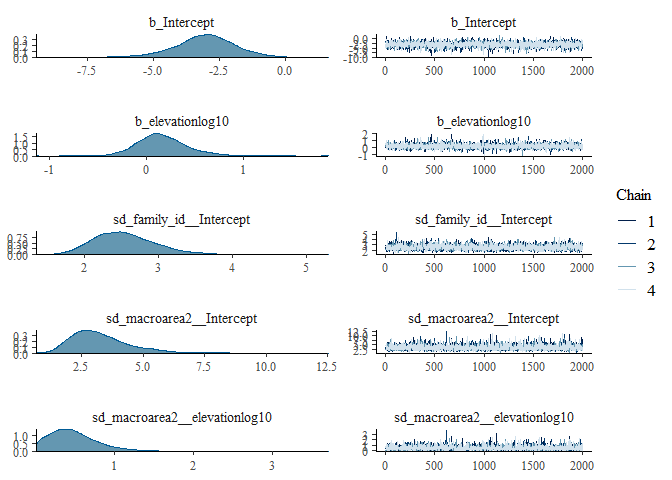

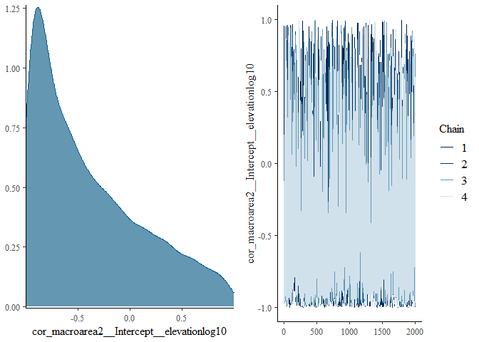

```r
plot(elevmodeluvulars)#
```

Inspect plots of observed data and posterior predictive samples

```r
pp_check(elevmodeluvulars)
```

```
## Using 10 posterior samples for ppc type 'dens_overlay' by default.
```

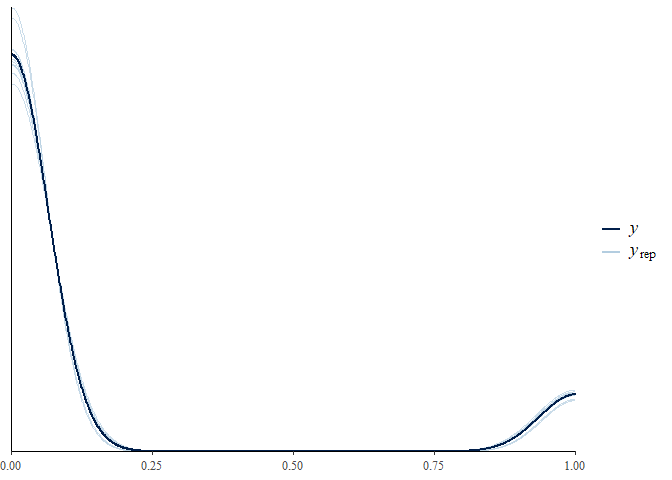

```r
pp_check(elevmodeluvulars, type="error_binned")
```

```
## Using 10 posterior samples for ppc type 'error_binned' by default.
```

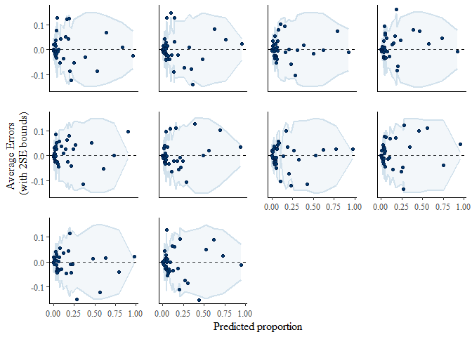

Assess predictive accuracy

```r
modelled_elevdata<-elevdata %>% drop_na(NonMarginal01, elevationlog10, macroarea2, family_id)
elevmodeluvulars_pred <- predict(elevmodeluvulars, type = "response")[ , "Estimate"]
elevmodeluvulars_pred <- as.numeric(elevmodeluvulars_pred > mean(modelled_elevdata$NonMarginal01))
(classtab_elevmodeluvulars <- table(predicted = elevmodeluvulars_pred, observed = modelled_elevdata$NonMarginal01))
```

```
##          observed
## predicted    0    1
##         0 1481   40
##         1  294  216
```

```r
(acc_elevmodeluvulars <- sum(diag(classtab_elevmodeluvulars)) / sum(classtab_elevmodeluvulars))
```

```
## [1] 0.835549
```

Assess posterior probability versus chance

```r
elevmodeluvularssamples<-posterior_samples(elevmodeluvulars)
sum(elevmodeluvularssamples$b_elevationlog10 < 0) /nrow(elevmodeluvularssamples)
```

```
## [1] 0.262875
```

### Model for ejectives

```r
elevmodelejectives<-brm(NonMarginal02 ~ elevationlog10 + (1+ elevationlog10| macroarea2) +(1|family_id), family= 'bernoulli', data=elevdata, warmup=6000, iter=8000, chains=4, prior=priors, control = list(adapt_delta = 0.99))
```

[output not shown]

[output cut: 58 more lines]

[output not shown]

Model assessment and checks

Check Rhat and ESS values

```r
summary(elevmodelejectives)
```

```
## Warning: There were 1 divergent transitions after warmup. Increasing adapt_delta
## above 0.99 may help. See http://mc-stan.org/misc/warnings.html#divergent-
## transitions-after-warmup

##  Family: bernoulli
##   Links: mu = logit
## Formula: NonMarginal02 ~ elevationlog10 + (1 + elevationlog10 | macroarea2) + (1 | family_id)
##    Data: elevdata (Number of observations: 2031)
## Samples: 4 chains, each with iter = 8000; warmup = 6000; thin = 1;
##          total post-warmup samples = 8000
##
## Group-Level Effects:
## ~family_id (Number of levels: 246)
##               Estimate Est.Error l-95% CI u-95% CI Rhat Bulk_ESS Tail_ESS
## sd(Intercept)     4.10      0.70     2.91     5.60 1.00     2401     3608
##
## ~macroarea2 (Number of levels: 11)
##                               Estimate Est.Error l-95% CI u-95% CI Rhat
## sd(Intercept)                     5.12      1.95     2.31     9.87 1.00
## sd(elevationlog10)                1.55      0.68     0.50     3.17 1.00
## cor(Intercept,elevationlog10)    -0.35      0.39    -0.92     0.52 1.00
##                               Bulk_ESS Tail_ESS
## sd(Intercept)                     3163     4299
## sd(elevationlog10)                2253     2145
## cor(Intercept,elevationlog10)     3317     3978
##
## Population-Level Effects:
##                Estimate Est.Error l-95% CI u-95% CI Rhat Bulk_ESS Tail_ESS
## Intercept         -8.83      2.16   -13.28    -4.80 1.00     3542     4678
## elevationlog10     1.57      0.70     0.15     2.93 1.00     2736     3499
##
## Samples were drawn using sampling(NUTS). For each parameter, Bulk_ESS
## and Tail_ESS are effective sample size measures, and Rhat is the potential
## scale reduction factor on split chains (at convergence, Rhat = 1).
```

Inspect chains

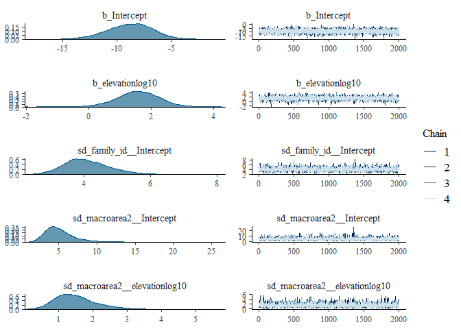

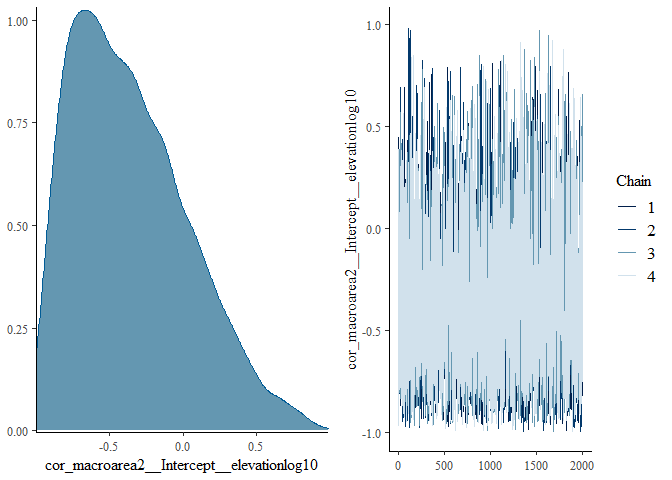

```r
plot(elevmodelejectives)
```

Inspect plots of observed data and posterior predictive samples

```r
pp_check(elevmodelejectives)
```

```
## Using 10 posterior samples for ppc type 'dens_overlay' by default.
```

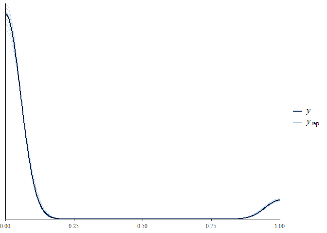

```r
pp_check(elevmodelejectives, type="error_binned")
```

```
## Using 10 posterior samples for ppc type 'error_binned' by default.
```

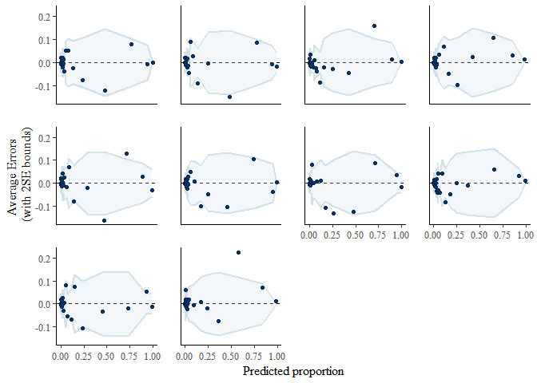

Assess predictive accuracy

```r
modelled_elevdata<-elevdata %>% drop_na(NonMarginal02, elevationlog10, macroarea2, family_id)
elevmodelejectives_pred <- predict(elevmodelejectives, type = "response")[ , "Estimate"]
elevmodelejectives_pred <- as.numeric(elevmodelejectives_pred > mean(modelled_elevdata$NonMarginal02))
(classtab_elevmodelejectives <- table(predicted = elevmodelejectives_pred, observed = modelled_elevdata$NonMarginal02))
```

```
##          observed
## predicted    0    1
##         0 1701   10
##         1  157  163
```

```r
(acc_elevmodelejectives <- sum(diag(classtab_elevmodelejectives)) / sum(classtab_elevmodelejectives))
```

```
## [1] 0.9177745
```

Assess posterior probability versus chance

```r
elevmodelejectivessamples<-posterior_samples(elevmodelejectives)
sum(elevmodelejectivessamples$b_elevationlog10 < 0) /nrow(elevmodelejectivessamples)
```

```
## [1] 0.0175
```

## By-area and by-family analysis

### By area

compute mean elevations and proportions of uvulars and ejectives per by area

```r
meanelevarea<-aggregate(elevation~macroarea2, FUN="mean", data=elevdata)
uvularproportionarea<-aggregate(NonMarginal01~macroarea2, FUN="mean", data=elevdata)
ejectiveproportionarea<-aggregate(NonMarginal02~macroarea2, FUN="mean", data=elevdata)
```

Least squares regression

```r
summary(lm(uvularproportionarea$NonMarginal01~meanelevarea$elevation))
```

```
##
## Call:
## lm(formula = uvularproportionarea$NonMarginal01 ~ meanelevarea$elevation)
##
## Residuals:
##      Min       1Q   Median       3Q      Max
## -0.18398 -0.10534 -0.06155  0.05564  0.46221
##
## Coefficients:
##                          Estimate Std. Error t value Pr(>|t|)
## (Intercept)            -0.0086059  0.1210039  -0.071   0.9449
## meanelevarea$elevation  0.0003090  0.0001444   2.140   0.0611 .
## ---
## Signif. codes:  0 '***' 0.001 '**' 0.01 '*' 0.05 '.' 0.1 ' ' 1
##
## Residual standard error: 0.2019 on 9 degrees of freedom
## Multiple R-squared:  0.3372, Adjusted R-squared:  0.2635
## F-statistic: 4.578 on 1 and 9 DF,  p-value: 0.06106
```

```r
summary(lm(ejectiveproportionarea$NonMarginal02~meanelevarea$elevation))
```

```
##
## Call:
## lm(formula = ejectiveproportionarea$NonMarginal02 ~ meanelevarea$elevation)
##
## Residuals:
##      Min       1Q   Median       3Q      Max
## -0.15446 -0.10677 -0.04525  0.06048  0.38299
##
## Coefficients:
##                         Estimate Std. Error t value Pr(>|t|)
## (Intercept)            8.622e-02  1.007e-01   0.856    0.414
## meanelevarea$elevation 5.188e-05  1.202e-04   0.432    0.676
##
## Residual standard error: 0.168 on 9 degrees of freedom
## Multiple R-squared:  0.02029,    Adjusted R-squared:  -0.08857
## F-statistic: 0.1864 on 1 and 9 DF,  p-value: 0.6761
```

Plot results

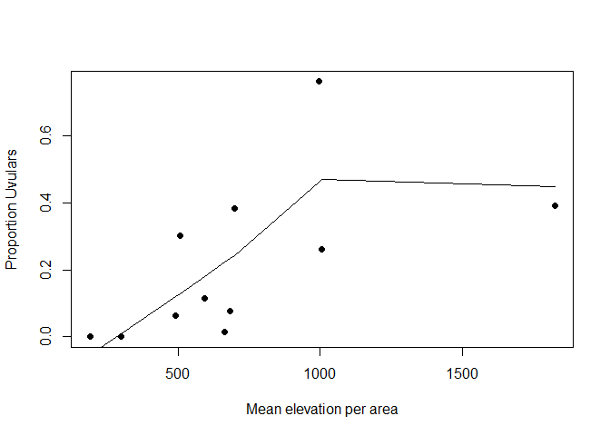

```r
plot(meanelevarea$elevation, uvularproportionarea$NonMarginal01, bg="black", pch=21, xlab="Mean elevation per area", ylab="Proportion Uvulars")
lines(lowess(meanelevarea$elevation, uvularproportionarea$NonMarginal01, f=10, iter=10))
```

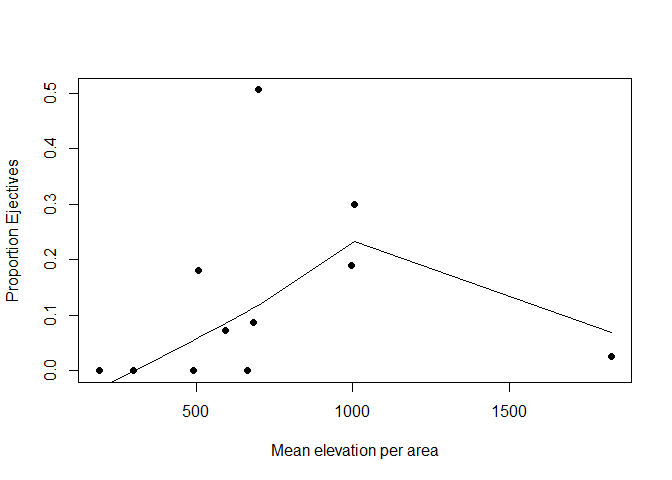

```r
plot(meanelevarea$elevation, ejectiveproportionarea$NonMarginal02, bg="black", pch=21, xlab="Mean elevation per area", ylab="Proportion Ejectives")
lines(lowess(meanelevarea$elevation, ejectiveproportionarea$NonMarginal02, f=10, iter=10))
```

### By family

```r
largefamilies<-filter(elevdata, family_id %in% c("afro1255", "araw1281", "atha1245", "atla1278", "aust1307", "cari1283", "gong1255", "mand1469", "maya1287", "mong1329", "nakh1245", "otom1299", "sali1255", "sino1245", "taik1256", "tupi1275", "turk1311", "ural1272"))
```

```r
meanelevfamily<-aggregate(elevation~family_id, FUN="mean", data=largefamilies)
uvularproportionfamily<-aggregate(NonMarginal01~family_id, FUN="mean", data=largefamilies)
ejectiveproportionfamily<-aggregate(NonMarginal02~family_id, FUN="mean", data=largefamilies)
```

Least squares regression

```r
summary(lm(uvularproportionfamily$NonMarginal01~meanelevfamily$elevation))
```

```
##
## Call:
## lm(formula = uvularproportionfamily$NonMarginal01 ~ meanelevfamily$elevation)
##
## Residuals:
##     Min      1Q  Median      3Q     Max
## -0.4004 -0.2081 -0.0997  0.1578  0.7765
##
## Coefficients:
##                           Estimate Std. Error t value Pr(>|t|)
## (Intercept)              0.1723016  0.1453521   1.185    0.253
## meanelevfamily$elevation 0.0001350  0.0001365   0.989    0.337
##
## Residual standard error: 0.3356 on 16 degrees of freedom
## Multiple R-squared:  0.05763,    Adjusted R-squared:  -0.001272
## F-statistic: 0.9784 on 1 and 16 DF,  p-value: 0.3373
```

```r
summary(lm(ejectiveproportionfamily$NonMarginal02~meanelevfamily$elevation))
```

```
##
## Call:
## lm(formula = ejectiveproportionfamily$NonMarginal02 ~ meanelevfamily$elevation)
##
## Residuals:
##     Min      1Q  Median      3Q     Max
## -0.5461 -0.2038 -0.1505  0.3385  0.7143
##
## Coefficients:
##                           Estimate Std. Error t value Pr(>|t|)
## (Intercept)              0.0743547  0.1696573   0.438    0.667
## meanelevfamily$elevation 0.0002262  0.0001593   1.420    0.175
##
## Residual standard error: 0.3917 on 16 degrees of freedom
## Multiple R-squared:  0.1119, Adjusted R-squared:  0.05636
## F-statistic: 2.015 on 1 and 16 DF,  p-value: 0.1749
```

Plot results

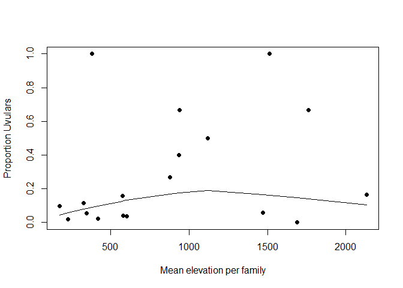

```r
plot(meanelevfamily$elevation, uvularproportionfamily$NonMarginal01, bg="black", pch=21, xlab="Mean elevation per family", ylab="Proportion Uvulars")
lines(lowess(meanelevfamily$elevation, uvularproportionfamily$NonMarginal01, f=10, iter=10))
```

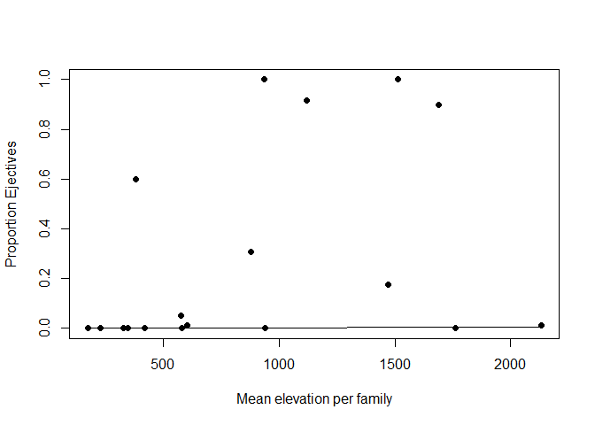

```r
plot(meanelevfamily$elevation, ejectiveproportionfamily$NonMarginal02, bg="black", pch=21, xlab="Mean elevation per family", ylab="Proportion Ejectives")
lines(lowess(meanelevfamily$elevation, ejectiveproportionfamily$NonMarginal02, f=10, iter=10))
```